# COMP2200: Week 3

Intro to Statistics in Data Science

A/Prof Benjamin Pope

School of Mathematical and Physical Sciences

2025-03-10

Welcome!

### In these lectures

#### Week 3

- Statistical basics
  - Mean, median and mode (what is an average?)
  - Standard deviation (how spread out are data?)
- Statistical graphics
  - Histograms
  - Scatter plots
- Distributions
  - random number generation
  - uniform, binomial distributions
  - central limit theorem and the normal distribution
  - multivariate distributions

#### Week 4

- Linear regression (fitting a line)
- Logistic regression (predicting categories)

#### Week 5

- Data privacy and ethics
- Software Engineering for Data Science

Who am I?

### My story

- grew up in Sydney
- undergrad, Honours **Sydney Uni** 2009-2012
  - in *physics*
- exchange at the **University of California in Berkeley** (San Francisco)
  - you should consider exchange too!
- Doctorate at **Oxford** 2013-2017
  - detecting planets with *Kepler*
- Postdoc at **New York University** 2017-2020
  - in data science *and* physics departments
  - more *Kepler* stuff, imaging planets, radio stars
- Lecturer at the **University of Queensland** 2021-2024
- Just started here - be patient!
- Don’t hesitate to ask anything - about stats, careers, or uni

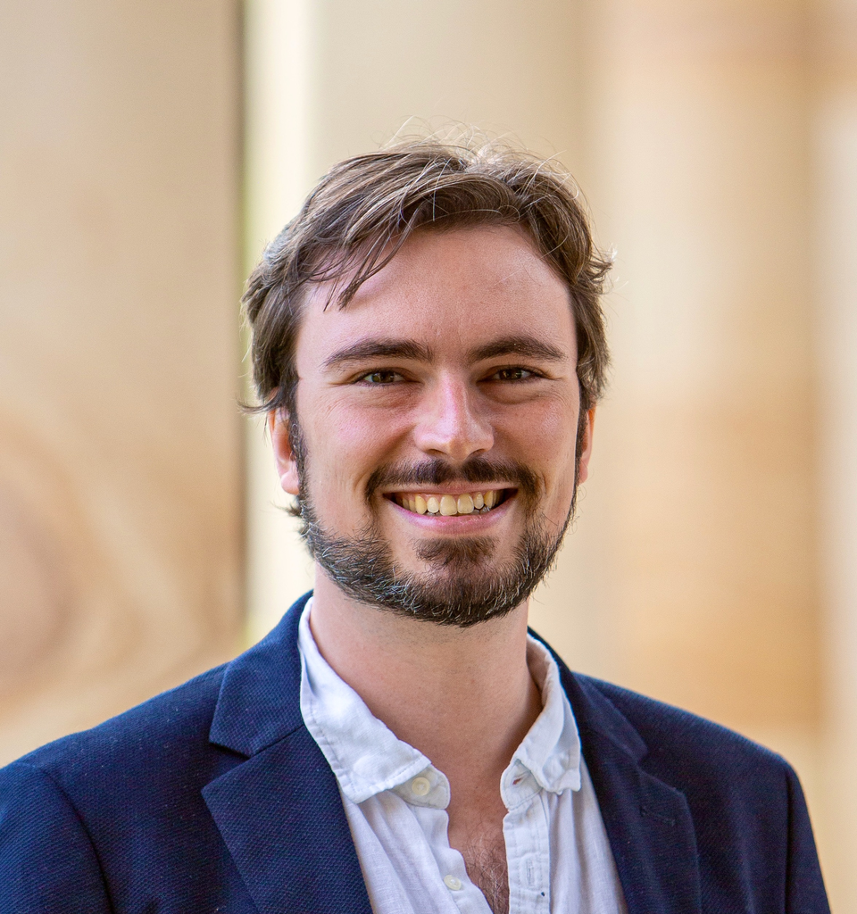

A/Prof Benjamin Pope (me)

### Why is an astronomer a statistician?

In my research, I want to

- learn how **stars** work
- detect **planets** around them
- develop **technology** for doing this better

[figure not shown]

James Webb Space Telescope

All of these problems are *data analysis* problems.

### What do we expect?

- you may or may not have a stats background - this is fine!
  - stats *is* data science and data science *is* stats - you want to learn this material well
- you may not have much experience with Python or Git - put work into getting good at these!
- come to lectures & meet your peers - this is really valuable!
- ask questions on the online discussion forum first, and feel free to email too - but it’s great if we can answer a question lots of people might have

What do we mean by statistics?

### What is data science?

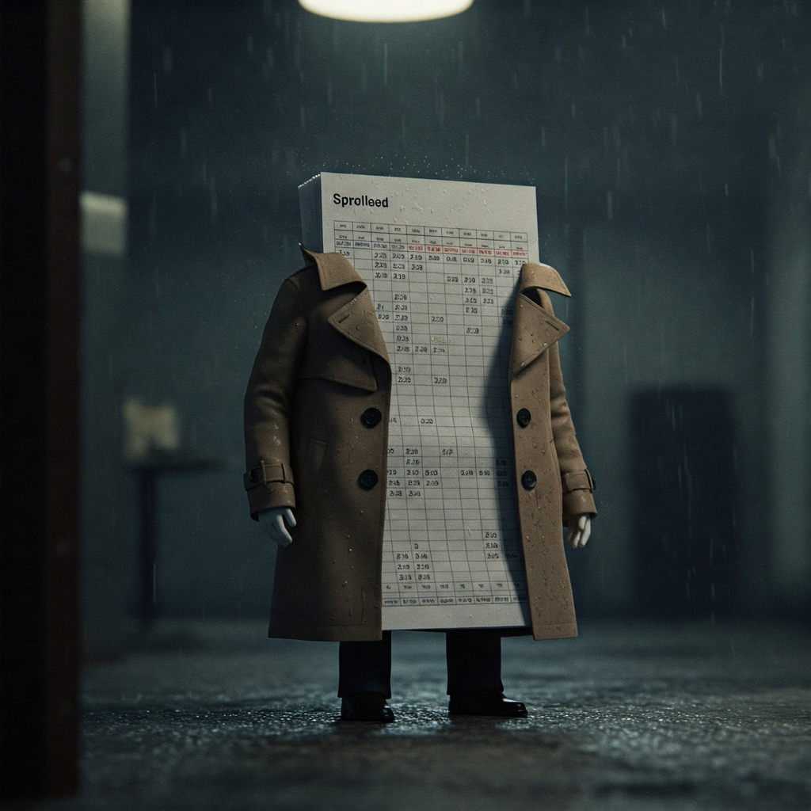

it’s stats

### What do *you* mean by statistics?

- the Census?
- spreadsheets?
- averages and standard deviations?
- probability theory?
- All of these things!

### What do *I* mean by statistics?

Statistics is the science of **reasoning about uncertainty**.

Data are always noisy and incomplete, and the art here is in properly accounting for this and getting *reliable, accurate, precise* results.

We’ll study how to

- gather data;
- visualize data;
- summarize data;
- fit models to data;
- interpret the models;
- and make decisions.

## Today

Let’s start with how to *gather, visualize and summarize data*.

### Public Datasets

There are a *lot* of data available in public sources. One is the [Australian Bureau of Statistics](https://tablebuilder.abs.gov.au/); we might use some of those later.

But another - which might help you get a job! - is [Kaggle](https://www.kaggle.com/), for data science competitions. They host public datasets and you can compete to produce the best models to explain and predict them.

### House Price Data

Let’s start with something that’s probably on everybody’s minds - a [Kaggle dataset on Sydney house prices](https://www.kaggle.com/datasets/alexlau203/sydney-house-prices?resource=download).

This comes as a `.csv` file: **c**omma **s**eparated **v**alues. It looks like this:

```
price,date_sold,suburb,num_bath,num_bed,num_parking,property_size,type,suburb_population,suburb_median_income,suburb_sqkm,suburb_lat,suburb_lng,suburb_elevation,cash_rate,property_inflation_index,km_from_cbd
530000,13/1/16,Kincumber,4,4,2,1351,House,7093,29432,9.914,-33.47252,151.40208,24,2,150.9,47.05
525000,13/1/16,Halekulani,2,4,2,594,House,2538,24752,1.397,-33.21772,151.55237,23,2,150.9,78.54
480000,13/1/16,Chittaway Bay,2,4,2,468,House,2028,31668,1.116,-33.32678,151.44557,3,2,150.9,63.59
452000,13/1/16,Leumeah,1,3,1,344,House,9835,32292,4.055,-34.05375,150.83957,81,2,150.9,40.12
365500,13/1/16,North Avoca,0,0,0,1850,Vacant land,2200,45084,1.497,-33.45608,151.43598,18,2,150.9,49.98
...
```

### Loading a CSV

We’re going to use [pandas](https://pypi.org/project/pandas/), an open source package for loading tables in Python; you’ll use this a lot!

```python
import pandas as pd

df = pd.read_csv('./domain_properties.csv') # df stands for DataFrame
print(df)
```

```
         price date_sold         suburb  num_bath  num_bed  num_parking  \
0       530000   13/1/16      Kincumber         4        4            2
1       525000   13/1/16     Halekulani         2        4            2
2       480000   13/1/16  Chittaway Bay         2        4            2
3       452000   13/1/16        Leumeah         1        3            1
4       365500   13/1/16    North Avoca         0        0            0
...        ...       ...            ...       ...      ...          ...
11155  1900000  31/12/21     Kellyville         3        4            2
11156  1300000  31/12/21    Seven Hills         3        7            2
11157  1025000  31/12/21         Sydney         2        2            1
11158  1087500    1/1/22       Prestons         2        4            2
11159  1000000    1/1/22       Ourimbah         2        3            2

       property_size                     type  suburb_population  \
0               1351                    House               7093
```

[output cut: 38 more lines]

So we see that a data frame has **columns**, each of which corresponds to some property of the data points, like `price`, `suburb`, etc. Every individual house sold is a **row** in this table.

### Selecting Data

Let’s look at only those data from 2021:

```python
#| code-line-numbers: "1|2|3"
df.year = pd.to_datetime(df.date_sold).dt.year # this is because dates in csv are strings but we want to extract year
df21 = df[df.year==2021]
print(df21)
```

```
         price date_sold              suburb  num_bath  num_bed  num_parking  \
5830   2800000   13/1/21           Wagstaffe         3        4            3
5831   1315000   13/1/21  The Entrance North         2        4            2
5832   2640000   14/1/21            Clovelly         3        5            0
5833   1825000   14/1/21          Willoughby         2        4            1
5834   1200000   14/1/21      Hamlyn Terrace         3        5            5
...        ...       ...                 ...       ...      ...          ...
11153  2055000  30/12/21         Carlingford         2        5            2
11154  1900000  30/12/21              Mascot         3        4            2
11155  1900000  31/12/21          Kellyville         3        4            2
11156  1300000  31/12/21         Seven Hills         3        7            2
11157  1025000  31/12/21              Sydney         2        2            1

       property_size                     type  suburb_population  \
5830             866                    House                222
```

[output cut: 38 more lines]

### Histograms

Now let’s make the most basic visualization of a dataset - a **histogram**.

You should almost always do this!

We are going to use another package you are going to learn inside and out: [matplotlib](https://matplotlib.org/).

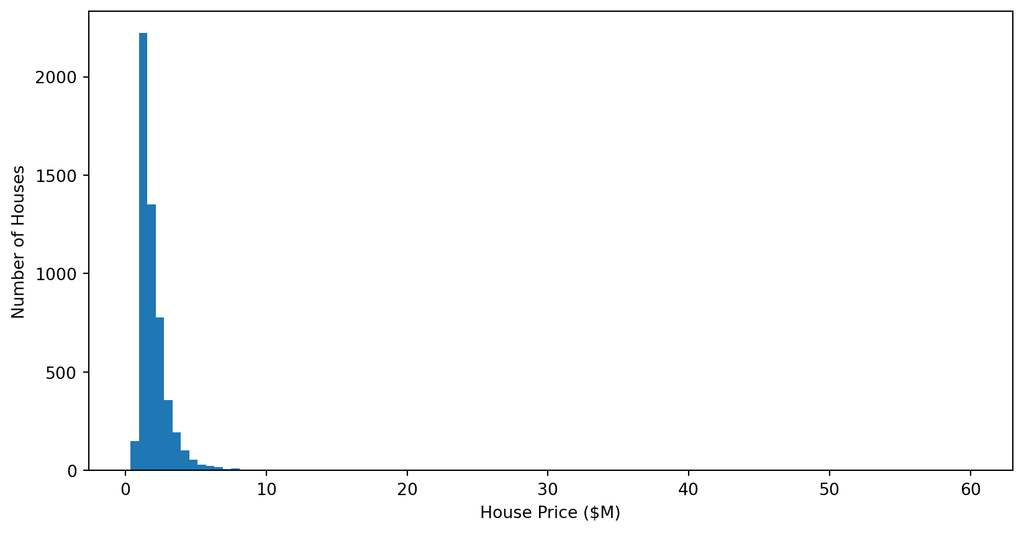

```python
import matplotlib.pyplot as plt # this makes plots in python
plt.hist(df21.price/1e6,bins=100); # semicolon to suppress output; /1e6 to make readable

plt.xlabel('House Price ($M)') # always label your axes!
plt.ylabel('Number of Houses');
```

### Filtering Data

There are some expensive houses in Sydney! Let’s look at the lower end:

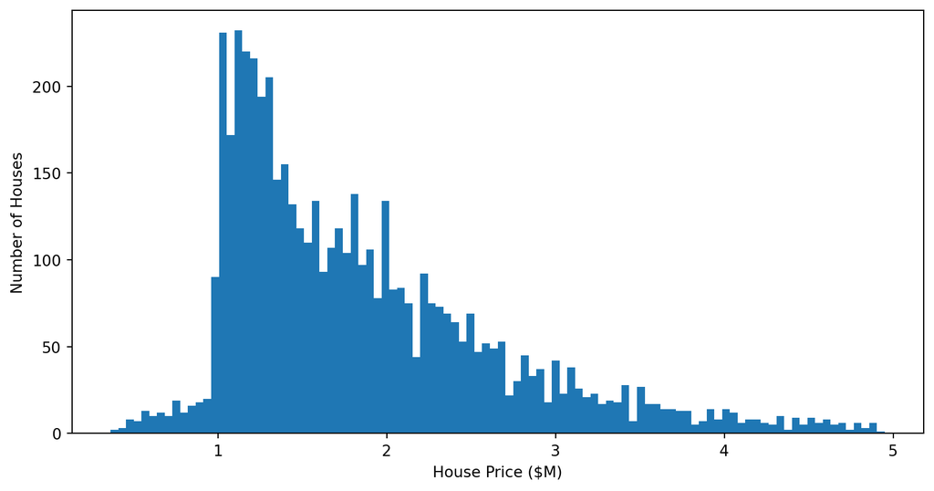

```python
realistic = df21[df21.price < 5e6]
plt.hist(realistic.price/1e6,bins=100); # semicolon to suppress output; /1e6 to make readable

plt.xlabel('House Price ($M)') # always label your axes!
plt.ylabel('Number of Houses');
```

### Summary Statistics

Let’s talk about the *mean*, the *median* and *percentiles*, and the *mode* as ways of talking about a distribution.

The *mean* is defined as
$$\langle{x}\rangle \equiv \frac{1}{N} \sum_{i=1}^{N} x_i$$

ie this is the contribution to the total, per item

The *median* is the value of $x$ such that 50% of samples are higher, and 50% are lower: i.e. the *middle* of the distribution. More generally, a *percentile* is defined so that (say) 90% of samples are less than the 90th percentile.

The *mode* is the most common value.

### NumPy

For doing maths like this on data, we want to use [numpy](https://numpy.org/), the standard Python package for numerical calculations:

```python
import numpy as np # always as np!
```

### Summary Statistics

Let’s plot the same histogram as above, but showing the summary statistics.

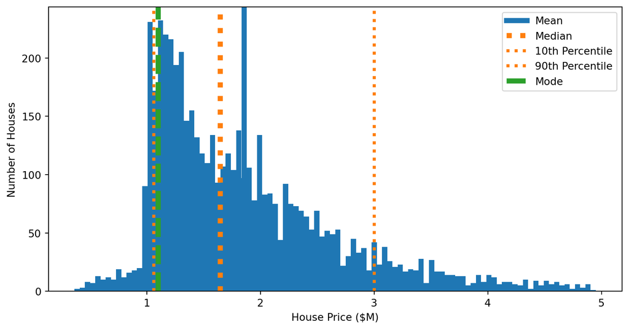

```python
h = plt.hist(realistic.price/1e6,bins=100); # semicolon to suppress output; /1e6 to make readable

plt.xlabel('House Price ($M)') # always label your axes!
plt.ylabel('Number of Houses')

plt.axvline(np.mean(realistic.price/1e6),
    ls='-',lw=5,color='C0',label = 'Mean')
plt.axvline(np.median(realistic.price/1e6),
    ls=':',lw=5,color='C1',label = 'Median')

for percentile in [10, 90]: # this is a for loop for doing multiple things
    plt.axvline(np.percentile(realistic.price/1e6,percentile),
            ls=':',color='C1', lw=3,label = f'{percentile}th Percentile') # this is an f-string for printing things

mode = np.argmax(h[0])
mode_price = h[1][mode]
plt.axvline(mode_price, ls='--', color='C2',lw=5, label='Mode')

plt.legend()
```

### Relationships

The core thing we want to do in data science is to make *inferences* from data. This means finding relationships in data to help us predict or understand what is happening.

Side note: *infer* vs *imply*. What’s the difference?

Data *imply* things *to us*.

We *infer* things *from data*.

### Trend Lines

Let’s see if we can plot a trend line for prices over time:

```python
years = np.arange(2016,2022,1) # integers up to 2021 - yes 2021
means, lowers, uppers = [], [], [] # init empty lists

for year in years:
    thisdf = df[df.year==year]
    means.append(np.mean(thisdf.price))
    lowers.append(np.percentile(thisdf.price,25))
    uppers.append(np.percentile(thisdf.price,75))
# make these into arrays
means, lowers, uppers = np.array(means), np.array(lowers), np.array(uppers)
```